# apples

Janith

2/17/2020

# Loading Data

Summary of the dataframe

```
##  Balance_Limit_V1 Gender       EDUCATION_STATUS MARITAL_STATUS
##  1M     :5951     F: 9540   Graduate   : 8478   Other :13070
##  200K   :5159     M:14460   High School: 3925   Single:10930
##  100K   :3449               Other      :11597
##  400K   :3065
##   500K  :2790
##  300K   :2411
##  (Other):1175
##            AGE           PAY_JULY        PAY_AUG         PAY_SEP
##  31-45       :12124   0      :11788   0      :12562   0      :12609
##  46-65       : 4150   -1     : 4534   -1     : 4847   -1     : 4730
##  Less than 30: 7638   1      : 2956   2      : 3150   -2     : 3240
##  More than 65:   88   -2     : 2205   -2     : 3014   2      : 3097
##                       2      : 2140   3      :  271   3      :  198
##                       3      :  258   4      :   84   4      :   65
##                       (Other):  119   (Other):   72   (Other):   61
##     PAY_OCT         PAY_NOV         PAY_DEC       DUE_AMT_JULY
##  0      :13199   0      :13581   0      :13045   Min.   :-382490
##  -1     : 4514   -1     : 4415   -1     : 4591   1st Qu.:   8246
##  -2     : 3453   -2     : 3605   -2     : 3885   Median :  51568
##  2      : 2548   2      : 2124   2      : 2231   Mean   : 118870
##  3      :  156   3      :  145   3      :  148   3rd Qu.: 156274
##  4      :   53   4      :   69   4      :   39   Max.   :2228020
##  (Other):   77   (Other):   61   (Other):   61
##   DUE_AMT_AUG       DUE_AMT_SEP       DUE_AMT_OCT       DUE_AMT_NOV
##  Min.   :-161185   Min.   :-142079   Min.   :-392700   Min.   :-187882
##  1st Qu.:   6969   1st Qu.:   6238   1st Qu.:   5429   1st Qu.:   4180
##  Median :  48717   Median :  46412   Median :  44105   Median :  41863
##  Mean   : 114073   Mean   : 109244   Mean   : 100357   Mean   :  93777
##  3rd Qu.: 148905   3rd Qu.: 140162   3rd Qu.: 126975   3rd Qu.: 116926
##  Max.   :2272881   Max.   :3844046   Max.   :2059564   Max.   :2141765
##
##   DUE_AMT_DEC      PAID_AMT_JULY      PAID_AMT_AUG      PAID_AMT_SEP
##  Min.   :-784483   Min.   :      0   Min.   :      0   Min.   :      0
##  1st Qu.:   2913   1st Qu.:   2310   1st Qu.:   1956   1st Qu.:    901
##  Median :  39409   Median :   4920   Median :   4646   Median :   4197
##  Mean   :  90341   Mean   :  13306   Mean   :  13867   Mean   :  12093
##  3rd Qu.: 114435   3rd Qu.:  11605   3rd Qu.:  11550   3rd Qu.:  10626
##  Max.   :2221444   Max.   :2017905   Max.   :3890638   Max.   :2069852
##
##   PAID_AMT_OCT      PAID_AMT_NOV     PAID_AMT_DEC     NEXT_MONTH_DEFAULT
##  Min.   :      0   Min.   :     0   Min.   :      0   0:18670
##  1st Qu.:    693   1st Qu.:   610   1st Qu.:    307   1: 5330
##  Median :   3465   Median :  3465   Median :   3465
##  Mean   :  11225   Mean   : 11175   Mean   :  12301
##  3rd Qu.:   9360   3rd Qu.:  9412   3rd Qu.:   9252
##  Max.   :1434510   Max.   :965557   Max.   :1221218
##
```

*There is a high class imabalance in the dataset*

# Categorical Variables

First let’s explore the Categorical variables. Since we are interested in what are the factors that affect the risk of credit card default, we shall be exploring considering the two levels of the response variable

### Gender

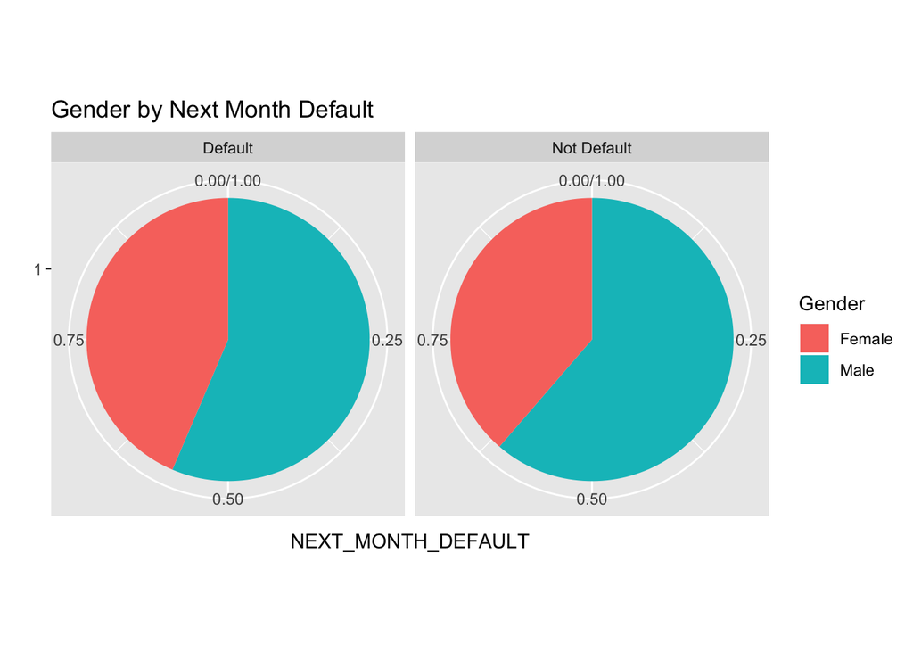

**As it can be clearly seen here, gender does not have a significant difference when compared with defaulting credit cards and not defaulting.**

### Marital status

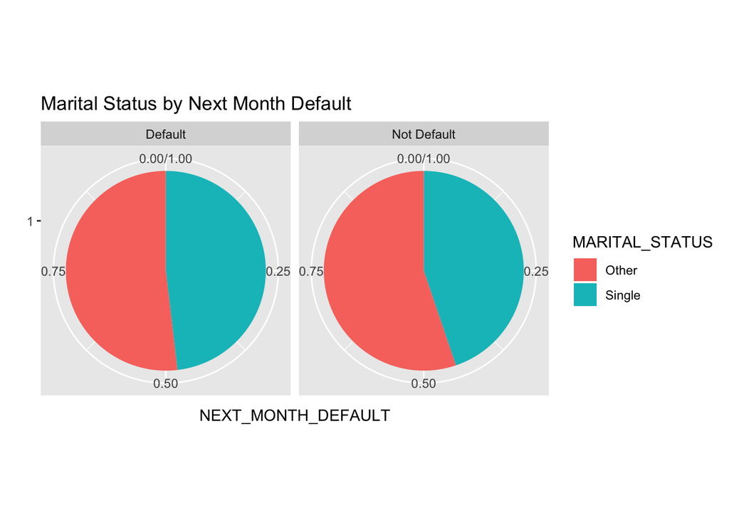

**As it can be clearly seen here, marital status does not have a significant difference when compared with defaulting credit cards and not defaulting.**

**Hence we have clear reasons for removing the variables gender and marital status**

### Education Status

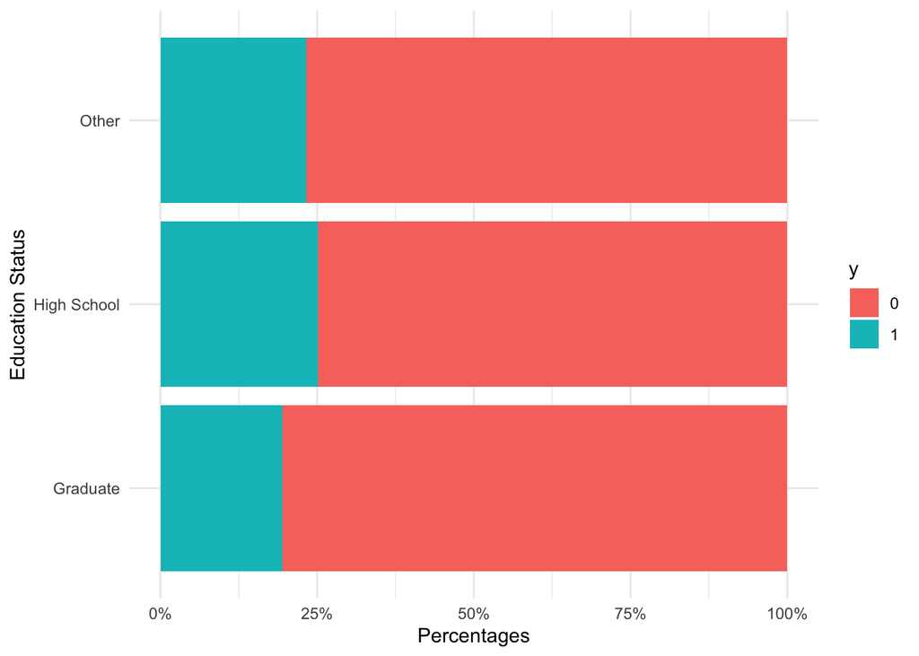

```
##
##  Pearson's Chi-squared test
##
## data:  train_df$EDUCATION_STATUS and train_df$NEXT_MONTH_DEFAULT
## X-squared = 63.292, df = 2, p-value = 1.804e-14
```

**Even though it is not evident that there is a relationship between education status and the response variable, the chi square test confirms that there is an association between the two variables** ### Balance Limit

```
##
##  Pearson's Chi-squared test
##
## data:  train_df$Balance_Limit_V1 and train_df$NEXT_MONTH_DEFAULT
## X-squared = 736.07, df = 7, p-value < 2.2e-16
```

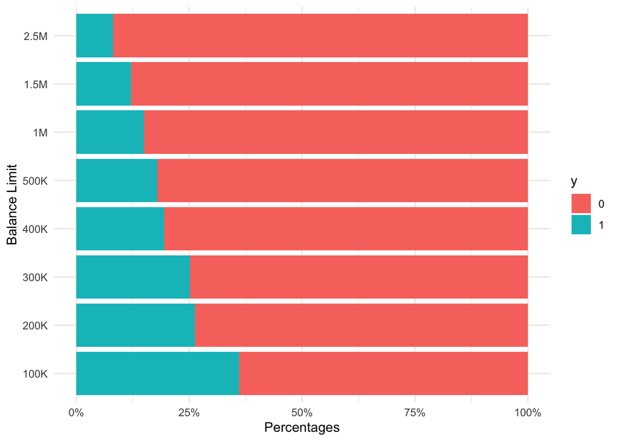

**Here it is clear that a client with a lower balance limit has a higher chance of getting a credit card default. Also from the chi square test it is clear that with a p-value less than alpha=0.05 we can reject H0 and come to the conclusion that there is balance limit and the response variable are not independent**

### Payment due variable

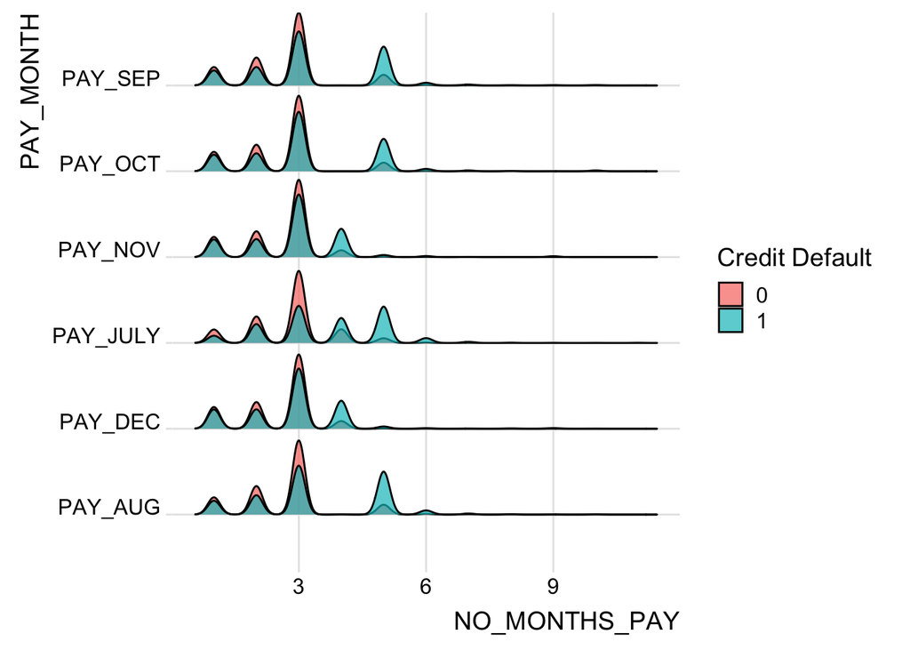

# Quantitative Variables

### Due amounts

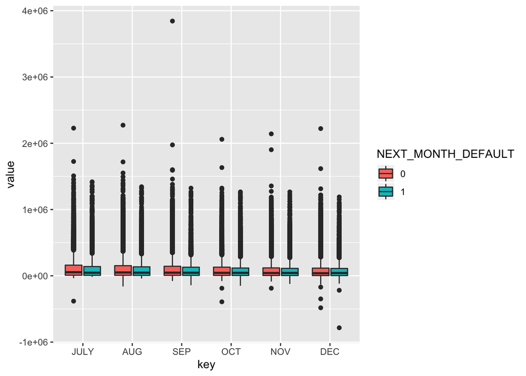

### Paid amounts

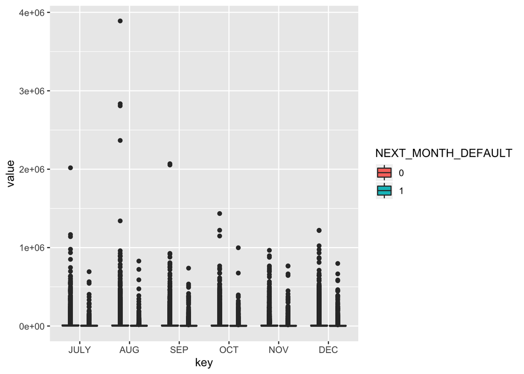

# Further visualizations

### Paid amount as a ratio of due amount

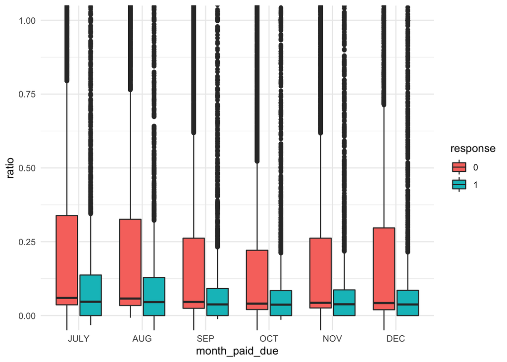

### Due amount as a ratio of credit limit

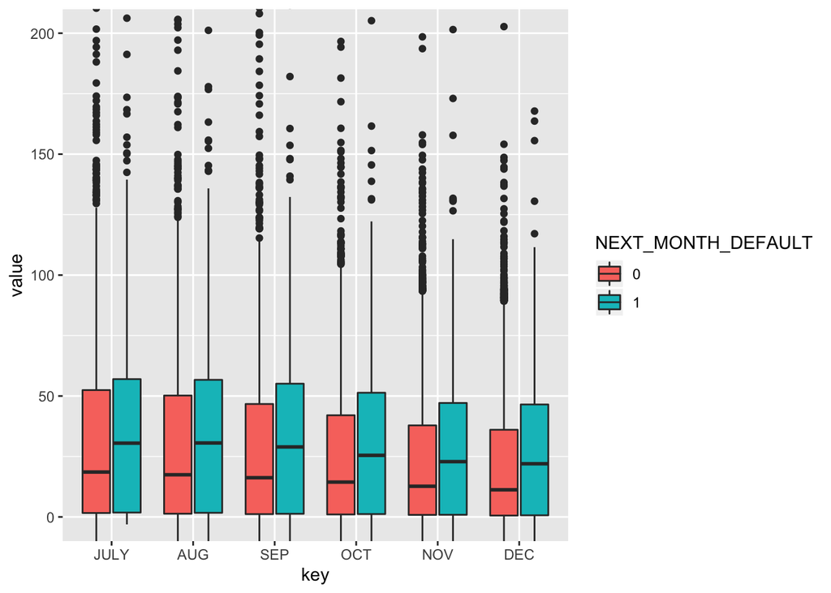

### Balance feature

Here we consider the balance as the `Due amount - Paid amount`

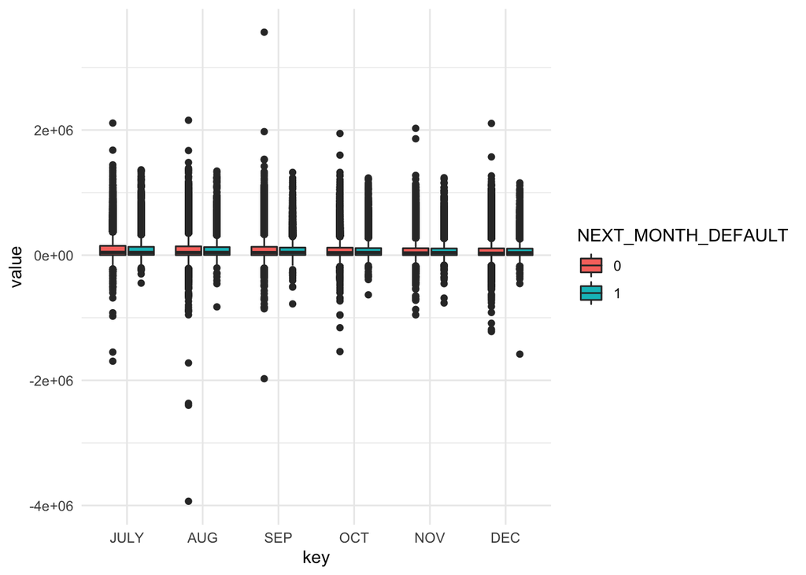

### Balance as a ratio of of credit limit

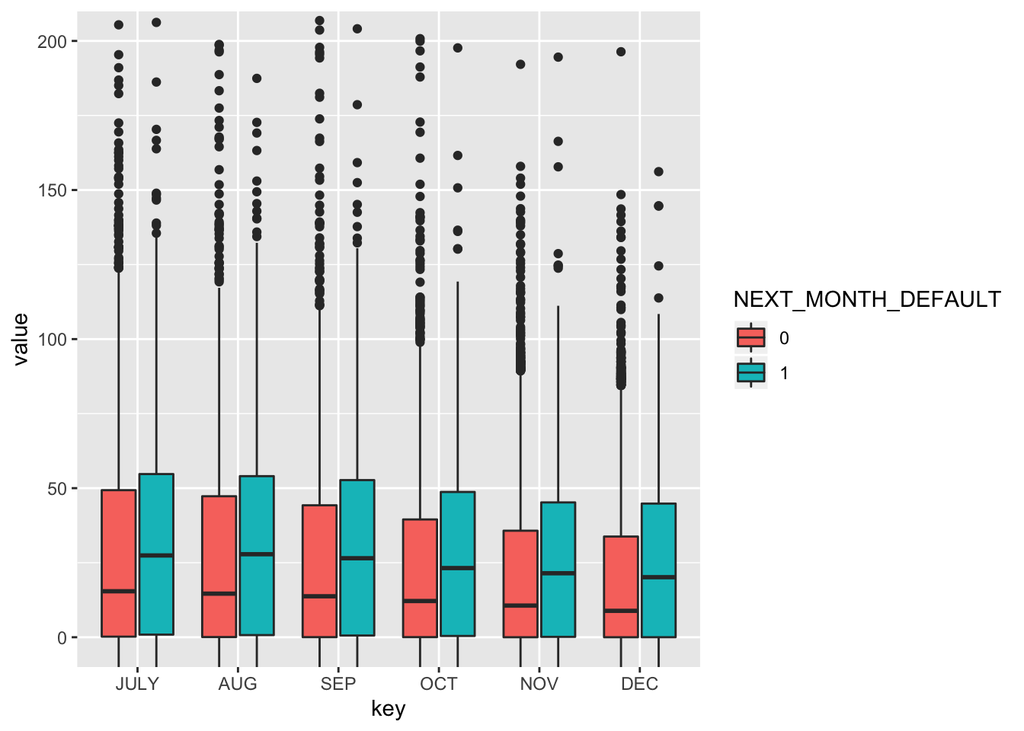

### Pay delay with the Paid value

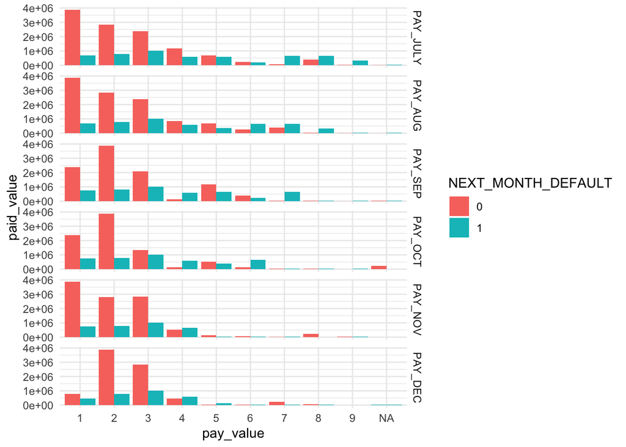

### Correlation matrix plot

Disregard this as it is too cluttered

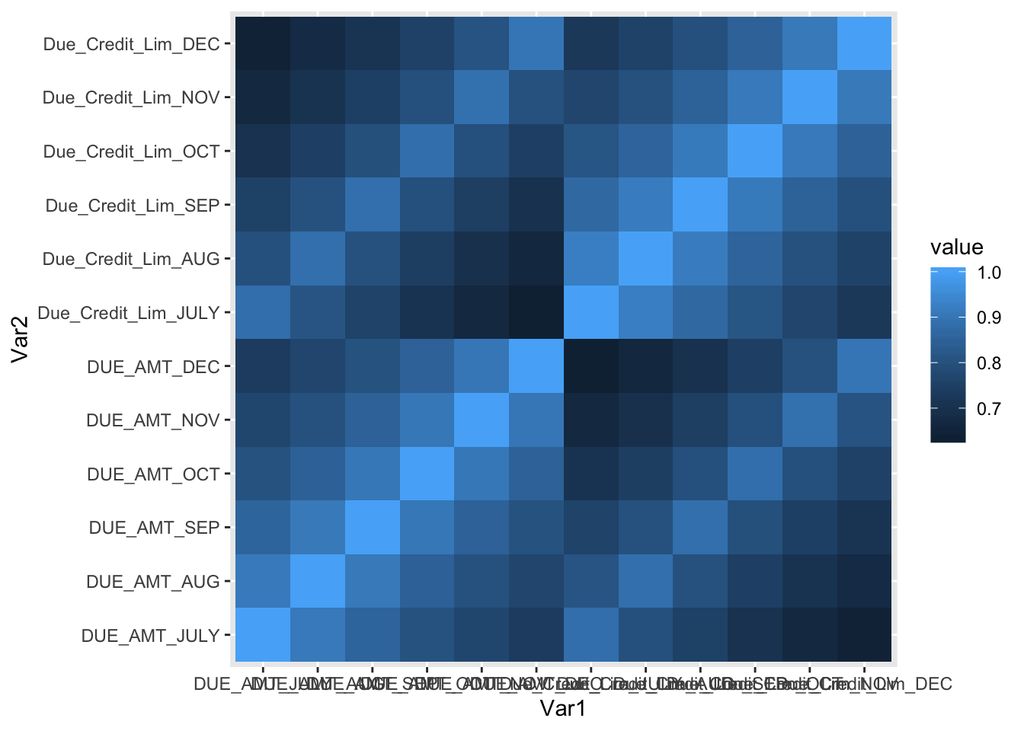